# Random R Notebook

# Bechdel Test

- 2+ named female chars
- they talk to each other
- talk about something besides a man

RichardOnData - tuorial 5

# Base R

search for built-in datasets `library(help= "datasets")`

see documentation of library `help(package = 'dplyr')`

```r
# help function opens documentation guide
? mean
```

```r
str(iris)
```

## summary function (Python .describe() )

`summary(iris)`

## names functions (Python column names)

`names(iris)`

## package installation

`install.package('dplyr')`

## load library

`library(dplyr)`

## function from a library

:: ``dplyr::select`

## load built-in library

`data(iris)`

## get working directory

`getwd()` `setwd()`

# vectors

`c(1,2,3)`

integer sequence `2:6`

a sequence of numbers with a step `seq(2,3, by= 0.5)`

repeating a vector `rep(1:4, times= 3)`

repeat elements in vector by n `rep(1:2, each= 3)` or `n= 3` ``rep(1:2, each= n)`

# Vector Functions

sort vector `sort(v)`

reverse vector order `rev(v)`

counts of values `table(v)`

see unique values `unique(v)`

# Select Vector Elements

get the 4th element `v[4]`

all but the 4th element `v[-4]`

# for loop

```r
for (i in k) {
  y = i**2
  print(y)
}
```

```
[1] 4
[1] 25
[1] 49
[1] 4.41
[1] 16
[1] 20.25
[1] 51.84
[1] 16.81
[1] 21.16
[1] 50.41
[1] 82.81
[1] 5.29
```

# while loop

```r
while(i < 15){
  i = i+2
  print(i)
}
```

[output not shown]

# Named function

```r
square = function(x){
  square = x**x
  print(square)
}
square(3)
```

```
[1] 27
```

# Random Normal Distribution

```r
# get 20 values, mean= 0, std= 1
rv = rnorm(20, 0, 1)
rv

plot(rv)
```

[output not shown]

# Density Function

```r
dv = dnorm(0, 0, 1)
dv
```

```
[1] 0.3989423
```

# Probability function

```r
# probability of getting 1.96
pv = pnorm(1.96, 0, 1)
pv
```

```
[1] 0.9750021
```

# Quantile function

```r
qv = qnorm(0.975, 0, 1)
qv
```

```
[1] 1.959964
```

# IfElse statement

using the ifelse() to get sepal lengths > 6 and sepal widths >3, check for condition, return True or False

```r
iris2 = iris %>%
  mutate(LargeSepal = ifelse(Sepal.Length > 6 & Sepal.Width > 3, T, F))
```

```
Error in iris %>% mutate(LargeSepal = ifelse(Sepal.Length > 6 & Sepal.Width >  :
  could not find function "%>%"
```

# Create a function

This function is temperature conversion from Fahrenheit to Celsius

```r
fahr =  c(76,78,65,71,55,58,76,81)

fahr.2.cels = function(x){
  y = (x - 32) * (5/9)
  return( round(y))
}

celsius = fahr.2.cels(fahr)
celsius
```

```
[1] 24 26 18 22 13 14 24 27
```

Accessing data frame column values

```r
# iris df $ column
iris$Sepal.Length
```

matrix notation for data frames

```r
iris[, 1]
```

# Binding columns of data frames

add a vector or data frame to another data frame using cbind()

```r
set.seed(555)
noise = rnorm(nrow(iris), 0,1)

cbin.example = cbind(iris, noise)
str(cbin.example)
```

```
'data.frame':   150 obs. of  6 variables:
 $ Sepal.Length: num  5.1 4.9 4.7 4.6 5 5.4 4.6 5 4.4 4.9 ...
 $ Sepal.Width : num  3.5 3 3.2 3.1 3.6 3.9 3.4 3.4 2.9 3.1 ...
 $ Petal.Length: num  1.4 1.4 1.3 1.5 1.4 1.7 1.4 1.5 1.4 1.5 ...
 $ Petal.Width : num  0.2 0.2 0.2 0.2 0.2 0.4 0.3 0.2 0.2 0.1 ...
 $ Species     : Factor w/ 3 levels "setosa","versicolor",..: 1 1 1 1 1 1 1 1 1 1 ...
 $ noise       : num  -0.33 0.504 0.374 1.889 -1.78 ...
```

# Binding rows of data frames

create a new data frame that is similar to iris dataset

```r
set.seed(555)

extraRows = data_frame(
  Sepal.Length = rnorm(50, 5, 1),
  Sepal.Width = runif(50, 2, 6),
  Petal.Length = rnorm(50, 1.5, 0.3),
  Petal.Width = runif(50, 0.1, 0.7),
  Species = factor( sample( c('setosa','versicolor', 'virginica'),
                            size = 50,
                            replace = T))
)

rbind.example = rbind(iris, extraRows)

str(iris)
str(extraRows)
str(extraRows)
```

[output not shown]

# using the `lm()` function for Linear Regression

```r
# don't break up the string without the escape backslash
Lin.Regr = lm( formula= "Sepal.Length ~ Sepal.Width + \
               Petal.Length + Petal.Width",
               data= iris)
summary(Lin.Regr)
```

```
Call:
lm(formula = "Sepal.Length ~ Sepal.Width + \n               Petal.Length + Petal.Width",
    data = iris)

Residuals:
     Min       1Q   Median       3Q      Max
-0.82816 -0.21989  0.01875  0.19709  0.84570

Coefficients:
             Estimate Std. Error t value Pr(>|t|)
(Intercept)   1.85600    0.25078   7.401 9.85e-12 ***
Sepal.Width   0.65084    0.06665   9.765  < 2e-16 ***
Petal.Length  0.70913    0.05672  12.502  < 2e-16 ***
Petal.Width  -0.55648    0.12755  -4.363 2.41e-05 ***
---
Signif. codes:  0 ‘***’ 0.001 ‘**’ 0.01 ‘*’ 0.05 ‘.’ 0.1 ‘ ’ 1

Residual standard error: 0.3145 on 146 degrees of freedom
Multiple R-squared:  0.8586,    Adjusted R-squared:  0.8557
F-statistic: 295.5 on 3 and 146 DF,  p-value: < 2.2e-16
```

# Generalized Linear Models `glm()`

this is used for Logistic Regression

```r
Log.Regr = glm( formula = "SepalGroup2 ~ Petal.Length + Petal.Width",
                data = iris,
                family = 'binomial')

summary(Log.Regr)
```

[output not shown]

```r
x = rnorm(n= 50, mean= 10, sd= 20)
x
```

```
 [1]  40.1914910  -4.3758406   9.3000224  -4.9523316 -15.0970630
 [6] -26.2098965  44.5139336 -21.4661794  37.3297566 -51.1529129
[11]  -8.9341404   7.8227113   0.7453966  40.4730445   6.0283060
[16]   6.4541036  10.4448605 -18.8052387  -1.3294089  47.2194517
[21]  44.1590309  20.4648993  31.2815258  16.5058865  -4.4870100
[26]  23.7975620  26.2076895  12.7126444  11.8298734   3.5907937
[31]  31.7118011   1.4767473  19.1141528  12.9776721  20.2327728
[36]  -3.9082455  17.6619327   3.7293026  30.7592375  14.1096926
[41]  -6.9856427   6.6910194  -1.9508979  27.3702979   6.3830047
[46]  35.3455699   3.6802011   4.5776868  10.6666014  -3.8655764
```

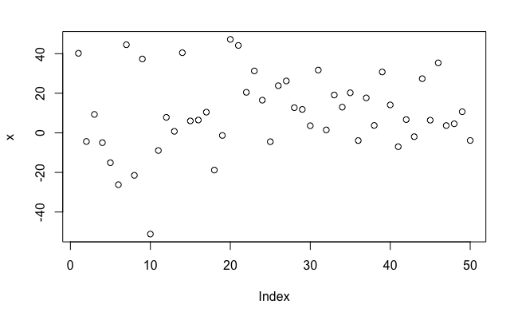

```r
plot(x)
```

```r
t.test(x= x, mu= 0, conf.level = 0.95)
```

```
    One Sample t-test

data:  x
t = 3.6606, df = 49, p-value = 0.0006157
alternative hypothesis: true mean is not equal to 0
95 percent confidence interval:
  4.636955 15.924656
sample estimates:
mean of x
 10.28081
```

```r
x = rnorm(n= 50, mean= 10, sd= 20)
t.test(x= x, mu= 4.515878, conf.level = 0.95)
```

```
    One Sample t-test

data:  x
t = 1.759, df = 49, p-value = 0.08482
alternative hypothesis: true mean is not equal to 4.515878
95 percent confidence interval:
  3.783278 15.533203
sample estimates:
mean of x
 9.658241
```

# working dates using libridate library

```r
yrInSeconds = dyears(x=1)
yrInSeconds
```

```
[1] "31557600s (~1 years)"
```

use **mutate** function to convert string format date data from CSV files to datetime format. Example file has column ‘date_time’

example_df = read.csv(“fake_file.csv”) example_df %>% mutate(date_time = mdy_hms(date_time))